# Capstone Project

```r
install.packages("ggplot2")
install.packages("corrplot")
install.packages("gridExtra")
install.packages("party")
installed.packages("class")
installed.packages("gmodels")
library(gridExtra)
library(corrplot)
library(class)
library(gmodels)
library(party)
library(ggplot2)
library(lubridate)
library(tidyverse)
library(caTools)
library(GGally)
```

```r
project=read.csv("C:/Users/dell/Downloads/archive/kc_house_data.csv",
                stringsAsFactors= FALSE, header = TRUE, sep = ",")
```

```r
head(project,10)
```

|  | id | date | price | bedrooms | bathrooms | sqft_living | sqft_lot | floors | waterfront | view | condition | grade | sqft_above | sqft_basement | yr_built | yr_renovated | zipcode | lat | long | sqft_living15 | sqft_lot15 |
| --- | --- | --- | --- | --- | --- | --- | --- | --- | --- | --- | --- | --- | --- | --- | --- | --- | --- | --- | --- | --- | --- |
| 1 | 7129300520 | 2014-10-13 | 221900 | 3 | 1.00 | 1180 | 5650 | 1 | 0 | 0 | 3 | 7 | 1180 | 0 | 1955 | 0 | 98178 | 47.5112 | -122.257 | 1340 | 5650 |
| 2 | 6414100192 | 2014-12-09 | 538000 | 3 | 2.25 | 2570 | 7242 | 2 | 0 | 0 | 3 | 7 | 2170 | 400 | 1951 | 1991 | 98125 | 47.7210 | -122.319 | 1690 | 7639 |
| 3 | 5631500400 | 2015-02-25 | 180000 | 2 | 1.00 | 770 | 10000 | 1 | 0 | 0 | 3 | 6 | 770 | 0 | 1933 | 0 | 98028 | 47.7379 | -122.233 | 2720 | 8062 |
| 4 | 2487200875 | 2014-12-09 | 604000 | 4 | 3.00 | 1960 | 5000 | 1 | 0 | 0 | 5 | NA | 1050 | 910 | 1965 | 0 | 98136 | 47.5208 | -122.393 | 1360 | 5000 |
| 5 | 1954400510 | 2015-02-18 | 510000 | 3 | 2.00 | 1680 | 8080 | 1 | 0 | 0 | 3 | 8 | 1680 | 0 | 1987 | 0 | 98074 | 47.6168 | -122.045 | 1800 | 7503 |
| 6 | 7237550310 | 2014-05-12 | 1230000 | 4 | 4.50 | 5420 | 101930 | 1 | 0 | 0 | 3 | 11 | 3890 | 1530 | 2001 | 0 | 98053 | 47.6561 | -122.005 | 4760 | 101930 |
| 7 | 1321400060 | 2014-06-27 | 257500 | 3 | 2.25 | 1715 | 6819 | 2 | 0 | 0 | 3 | 7 | 1715 | 0 | 1995 | 0 | 98003 | 47.3097 | -122.327 | 2238 | 6819 |
| 8 | 2008000270 | 2015-01-15 | 291850 | 3 | 1.50 | 1060 | 9711 | 1 | 0 | 0 | 3 | NA | 1060 | 0 | 1963 | 0 | 98198 | 47.4095 | -122.315 | 1650 | 9711 |
| 9 | 2414600126 | 2015-04-15 | 229500 | 3 | 1.00 | 1780 | 7470 | 1 | 0 | 0 | 3 | NA | 1050 | 730 | 1960 | 0 | 98146 | 47.5123 | -122.337 | 1780 | 8113 |
| 10 | 3793500160 | 2015-03-12 | 323000 | 3 | 2.50 | 1890 | 6560 | 2 | 0 | 0 | 3 | NA | 1890 | 0 | 2003 | 0 | 98038 | 47.3684 | -122.031 | 2390 | 7570 |

```r
str(project)
```

```
'data.frame':   21613 obs. of  21 variables:
 $ id           : num  7.13e+09 6.41e+09 5.63e+09 2.49e+09 1.95e+09 ...
 $ date         : chr  "2014-10-13" "2014-12-09" "2015-02-25" "2014-12-09" ...
 $ price        : num  221900 538000 180000 604000 510000 ...
 $ bedrooms     : int  3 3 2 4 3 4 3 3 3 3 ...
 $ bathrooms    : num  1 2.25 1 3 2 4.5 2.25 1.5 1 2.5 ...
 $ sqft_living  : int  1180 2570 770 1960 1680 5420 1715 1060 1780 1890 ...
 $ sqft_lot     : int  5650 7242 10000 5000 8080 101930 6819 9711 7470 6560 ...
 $ floors       : num  1 2 1 1 1 1 2 1 1 2 ...
 $ waterfront   : int  0 0 0 0 0 0 0 0 0 0 ...
 $ view         : int  0 0 0 0 0 0 0 0 0 0 ...
 $ condition    : int  3 3 3 5 3 3 3 3 3 3 ...
 $ grade        : int  7 7 6 NA 8 11 7 NA NA NA ...
 $ sqft_above   : int  1180 2170 770 1050 1680 3890 1715 1060 1050 1890 ...
 $ sqft_basement: int  0 400 0 910 0 1530 0 0 730 0 ...
 $ yr_built     : int  1955 1951 1933 1965 1987 2001 1995 1963 1960 2003 ...
 $ yr_renovated : int  0 1991 0 0 0 0 0 0 0 0 ...
 $ zipcode      : int  98178 98125 98028 98136 98074 98053 98003 98198 98146 98038 ...
 $ lat          : num  47.5 47.7 47.7 47.5 47.6 ...
 $ long         : num  -122 -122 -122 -122 -122 ...
 $ sqft_living15: int  1340 1690 2720 1360 1800 4760 2238 1650 1780 2390 ...
 $ sqft_lot15   : int  5650 7639 8062 5000 7503 101930 6819 9711 8113 7570 ...
```

```r
summary(project)
```

```
       id                date               price            bedrooms        bathrooms      sqft_living
 Min.   :1.000e+06   Length:21613       Min.   :  75000   Min.   : 0.000   Min.   :0.000   Min.   :  290
 1st Qu.:2.123e+09   Class :character   1st Qu.: 321950   1st Qu.: 3.000   1st Qu.:1.750   1st Qu.: 1427
 Median :3.905e+09   Mode  :character   Median : 450000   Median : 3.000   Median :2.250   Median : 1910
 Mean   :4.580e+09                      Mean   : 540182   Mean   : 3.371   Mean   :2.115   Mean   : 2080
 3rd Qu.:7.309e+09                      3rd Qu.: 645000   3rd Qu.: 4.000   3rd Qu.:2.500   3rd Qu.: 2550
 Max.   :9.900e+09                      Max.   :7700000   Max.   :33.000   Max.   :8.000   Max.   :13540

    sqft_lot           floors        waterfront            view          condition         grade
 Min.   :    520   Min.   :1.000   Min.   :0.000000   Min.   :0.0000   Min.   :1.000   Min.   : 1.000
 1st Qu.:   5040   1st Qu.:1.000   1st Qu.:0.000000   1st Qu.:0.0000   1st Qu.:3.000   1st Qu.: 7.000
 Median :   7618   Median :1.500   Median :0.000000   Median :0.0000   Median :3.000   Median : 7.000
 Mean   :  15107   Mean   :1.494   Mean   :0.007542   Mean   :0.2343   Mean   :3.409   Mean   : 7.657
 3rd Qu.:  10688   3rd Qu.:2.000   3rd Qu.:0.000000   3rd Qu.:0.0000   3rd Qu.:4.000   3rd Qu.: 8.000
 Max.   :1651359   Max.   :3.500   Max.   :1.000000   Max.   :4.0000   Max.   :5.000   Max.   :13.000
                                                                                       NA's   :19
   sqft_above   sqft_basement       yr_built     yr_renovated       zipcode           lat
 Min.   : 290   Min.   :   0.0   Min.   :1900   Min.   :   0.0   Min.   :98001   Min.   :47.16
 1st Qu.:1190   1st Qu.:   0.0   1st Qu.:1951   1st Qu.:   0.0   1st Qu.:98033   1st Qu.:47.47
 Median :1560   Median :   0.0   Median :1975   Median :   0.0   Median :98065   Median :47.57
 Mean   :1788   Mean   : 291.5   Mean   :1971   Mean   :  84.4   Mean   :98078   Mean   :47.56
 3rd Qu.:2210   3rd Qu.: 560.0   3rd Qu.:1997   3rd Qu.:   0.0   3rd Qu.:98118   3rd Qu.:47.68
 Max.   :9410   Max.   :4820.0   Max.   :2015   Max.   :2015.0   Max.   :98199   Max.   :47.78

      long        sqft_living15    sqft_lot15
 Min.   :-122.5   Min.   : 399   Min.   :   651
 1st Qu.:-122.3   1st Qu.:1490   1st Qu.:  5100
 Median :-122.2   Median :1840   Median :  7620
 Mean   :-122.2   Mean   :1987   Mean   : 12768
 3rd Qu.:-122.1   3rd Qu.:2360   3rd Qu.: 10083
 Max.   :-121.3   Max.   :6210   Max.   :871200
```

# Data Cleaning

```r
project$date = as.Date(project$date)
str(project)
```

```
'data.frame':   21613 obs. of  21 variables:
 $ id           : num  7.13e+09 6.41e+09 5.63e+09 2.49e+09 1.95e+09 ...
 $ date         : Date, format: "2014-10-13" "2014-12-09" "2015-02-25" ...
 $ price        : num  221900 538000 180000 604000 510000 ...
 $ bedrooms     : int  3 3 2 4 3 4 3 3 3 3 ...
 $ bathrooms    : num  1 2.25 1 3 2 4.5 2.25 1.5 1 2.5 ...
 $ sqft_living  : int  1180 2570 770 1960 1680 5420 1715 1060 1780 1890 ...
 $ sqft_lot     : int  5650 7242 10000 5000 8080 101930 6819 9711 7470 6560 ...
 $ floors       : num  1 2 1 1 1 1 2 1 1 2 ...
 $ waterfront   : int  0 0 0 0 0 0 0 0 0 0 ...
 $ view         : int  0 0 0 0 0 0 0 0 0 0 ...
 $ condition    : int  3 3 3 5 3 3 3 3 3 3 ...
 $ grade        : int  7 7 6 NA 8 11 7 NA NA NA ...
 $ sqft_above   : int  1180 2170 770 1050 1680 3890 1715 1060 1050 1890 ...
 $ sqft_basement: int  0 400 0 910 0 1530 0 0 730 0 ...
 $ yr_built     : int  1955 1951 1933 1965 1987 2001 1995 1963 1960 2003 ...
 $ yr_renovated : int  0 1991 0 0 0 0 0 0 0 0 ...
 $ zipcode      : int  98178 98125 98028 98136 98074 98053 98003 98198 98146 98038 ...
 $ lat          : num  47.5 47.7 47.7 47.5 47.6 ...
 $ long         : num  -122 -122 -122 -122 -122 ...
 $ sqft_living15: int  1340 1690 2720 1360 1800 4760 2238 1650 1780 2390 ...
 $ sqft_lot15   : int  5650 7639 8062 5000 7503 101930 6819 9711 8113 7570 ...
```

```r
dim(project)
```

```
[1] 21613    21
```

```r
NA_values=data.frame(no_of_na_values=colSums(is.na(project)))
head(NA_values,21)
```

|  | no_of_na_values |
| --- | --- |
| id | 0 |
| date | 0 |
| price | 0 |
| bedrooms | 0 |
| bathrooms | 0 |
| sqft_living | 0 |
| sqft_lot | 0 |
| floors | 0 |
| waterfront | 0 |
| view | 0 |

[output cut: 11 more lines]

```r
sum(NA_values)
```

```
[1] 19
```

```r
which(is.na(project))
```

```
 [1] 237747 237751 237752 237753 237754 237755 237756 237757 237758 237759 237760 237761 237762 237763 237764
[16] 237765 237766 237767 237768
```

```r
gradeMean=mean(project$grade, na.rm = TRUE)  #indexing
project[is.na(project$grade),"grade"]=gradeMean
project$grade = as.integer(project$grade)
View(project$grade)
```

```r
sum(is.na(project))
```

```
[1] 0
```

#removing the column which do not provide any information about housing

```r
project$id = NULL
View(project)
```

#converting the price from Dollar to units of 1000 Dollar to improve readability.

```r
project$price = project$price / 1000
```

#density of the price to get a first impression on its distribution

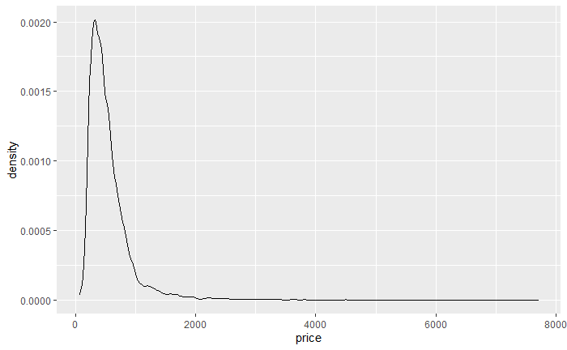

```r
ggplot(project, aes(x = price)) + geom_density()
```

```r
range(project$price)
```

```
[1]   75 7700
```

```r
#min(range(project$price))
#max(range(project$price))
```

# Dividing data into test and train set

```r
set.seed(1)
sample <- sample(c(TRUE, FALSE), nrow(project), replace=TRUE, prob=c(0.7,0.3))
#  set seed to ensure you always have same random numbers generated
#sample = sample.split(project,SplitRatio = 0.8) # splits the data in the ratio mentioned in SplitRatio. After splitting marks these rows as logical TRUE and the the remaining are marked as logical FALSE
#train_data =subset(project,sample ==TRUE) # creates a training dataset named train1 with rows which are marked as TRUE
#test_data=subset(project, sample==FALSE)
train_data<- project[sample, ]
test_data<- project[!sample, ]
```

#Determining the association between variables.

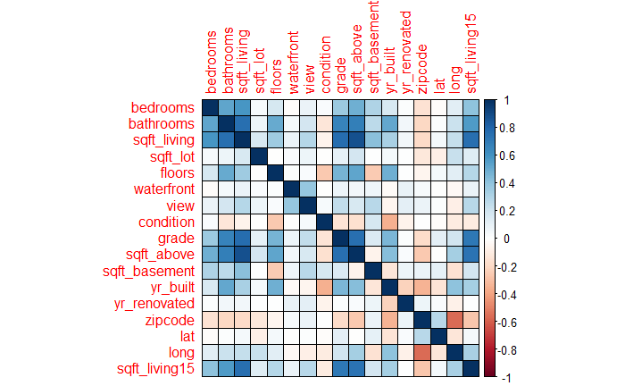

```r
cor_data=data.frame(train_data[,3:19])
correlation=cor(cor_data)
corrplot(correlation,method="color",outline="black", insig = "p-value")
```

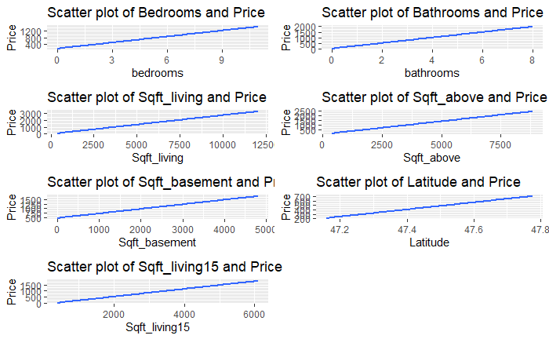

```r
p1=ggplot(data = train_data, aes(x = bedrooms, y = price)) +  geom_smooth(method = "lm", se = FALSE)+labs(title="Scatter plot of Bedrooms and Price", x="bedrooms",y="Price")
p2=ggplot(data = train_data, aes(x = bathrooms, y = price))  +  geom_smooth(method = "lm", se = FALSE)+labs(title="Scatter plot of Bathrooms and Price", x="bathrooms",y="Price")
p3=ggplot(data = train_data, aes(x = sqft_living, y = price)) +  geom_smooth(method = "lm", se = FALSE)+labs(title="Scatter plot of Sqft_living and Price", x="Sqft_living",y="Price")
p4=ggplot(data = train_data, aes(x = sqft_above, y = price)) +  geom_smooth(method = "lm", se = FALSE)+labs(title="Scatter plot of Sqft_above and Price", x="Sqft_above",y="Price")
p5=ggplot(data = train_data, aes(x = sqft_basement, y = price)) +  geom_smooth(method = "lm", se = FALSE)+labs(title="Scatter plot of Sqft_basement and Price", x="Sqft_basement",y="Price")
p6=ggplot(data = train_data, aes(x = lat, y = price)) +  geom_smooth(method = "lm", se = FALSE)+labs(title="Scatter plot of Latitude and Price", x="Latitude",y="Price")
p7=ggplot(data = train_data, aes(x = sqft_living15, y = price)) +  geom_smooth(method = "lm", se = FALSE)+labs(title="Scatter plot of Sqft_living15 and Price", x="Sqft_living15",y="Price")
grid.arrange(p1,p2,p3,p4,p5,p6,p7,nrow=4)
```

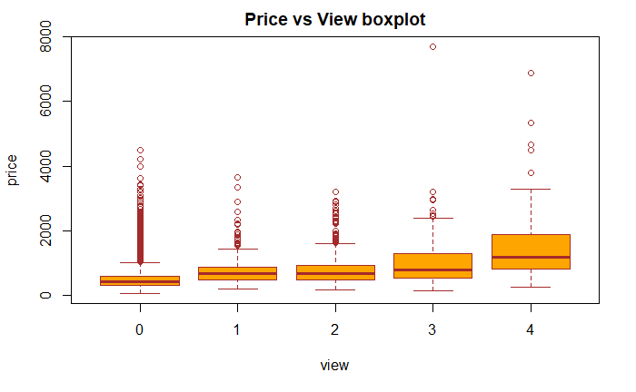

```r
#par(mfrow=c(1, 2))
boxplot(price~view,data=train_data,main="Price vs View boxplot", xlab="view",ylab="price",col="orange",border="brown")
```

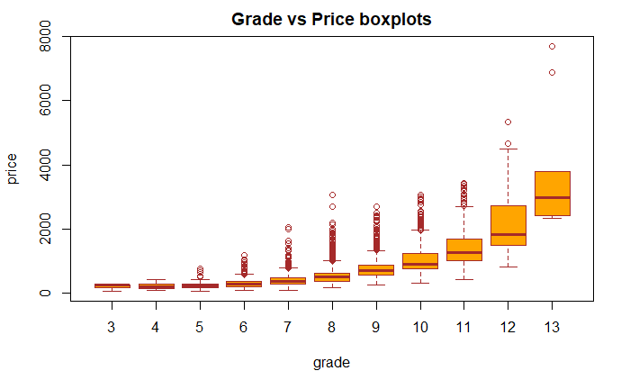

```r
boxplot(price~grade,data=train_data,main="Grade vs Price boxplots", xlab="grade",ylab="price",col="orange",border="brown")
```

#now we check for outliers in the dependent variable(price) using a boxplot.

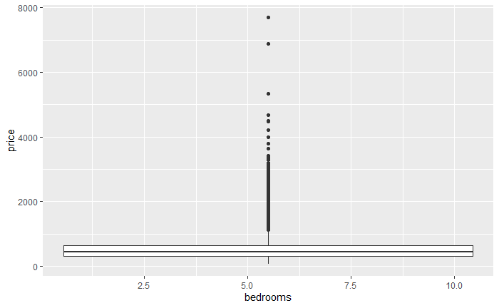

```r
ggplot(data=train_data)+geom_boxplot(aes(x=bedrooms,y=price))
```

#we see that we have a significantly large number of outliers. #Treating or altering the outlier/extreme values in genuine observations is not a standard operating procedure. However, it is essential to understand their impact on our predictive models. #To better understand the implications of outliers better, I am going to compare the fit of a simple linear regression model on the dataset with and without outliers. #For this we first extract outliers from the data and then obtain the data without the outliers.

```r
train_data$age=train_data$date-train_data$yr_built #age of the house
train_data$reno=ifelse(train_data$yr_renovated==0,0,1) # number of times renovated
train_data$reno=as.factor(train_data$reno)
test_data$age=test_data$date-test_data$yr_built #age of the house
test_data$reno=ifelse(test_data$yr_renovated==0,0,1) # number of times renovated
test_data$reno=as.factor(test_data$reno)
```

```r
outliers=boxplot(train_data$price,plot=FALSE)$out
outliers_data=train_data[which(train_data$price %in% outliers),]
train_data1= train_data[-which(train_data$price %in% outliers),]
```

```r
par(mfrow=c(1, 2))
plot(train_data$bedrooms, train_data$price, main="With Outliers", xlab="bedrooms", ylab="price", pch="*", col="red", cex=2)
abline(lm(price ~ bedrooms, data=train_data), col="blue", lwd=3, lty=2)
```

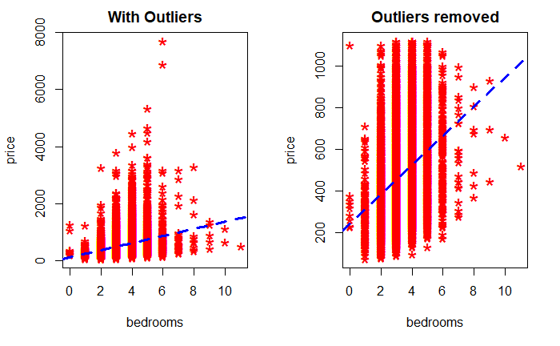

```r
# Plot of original data without outliers. Note the change of slope.
plot(train_data1$bedrooms, train_data1$price, main="Outliers removed", xlab="bedrooms", ylab="price", pch="*", col="red", cex=2)
abline(lm(price ~bedrooms, data=train_data1), col="blue", lwd=3, lty=2)
```

#MODELING

```r
model=lm(data=train_data,price~bedrooms+bathrooms+sqft_living+view+grade+sqft_above+sqft_basement+sqft_living15)
summary(model)
```

```
Call:
lm(formula = price ~ bedrooms + bathrooms + sqft_living + view +
    grade + sqft_above + sqft_basement + sqft_living15, data = train_data)

Residuals:
    Min      1Q  Median      3Q     Max
-1252.1  -124.7   -19.0    95.9  4636.8

Coefficients: (1 not defined because of singularities)
                Estimate Std. Error t value Pr(>|t|)
(Intercept)   -4.805e+02  1.736e+01 -27.675  < 2e-16 ***
bedrooms      -3.290e+01  2.704e+00 -12.168  < 2e-16 ***
bathrooms     -1.520e+01  3.942e+00  -3.856 0.000116 ***
sqft_living    2.209e-01  5.625e-03  39.269  < 2e-16 ***
view           8.853e+01  2.732e+00  32.405  < 2e-16 ***
grade          9.758e+01  2.850e+00  34.244  < 2e-16 ***
sqft_above    -4.068e-02  5.224e-03  -7.786 7.38e-15 ***
sqft_basement         NA         NA      NA       NA
sqft_living15  3.893e-03  4.610e-03   0.844 0.398475
---
Signif. codes:  0 ‘***’ 0.001 ‘**’ 0.01 ‘*’ 0.05 ‘.’ 0.1 ‘ ’ 1

Residual standard error: 234.7 on 15096 degrees of freedom
Multiple R-squared:  0.5792,    Adjusted R-squared:  0.579
F-statistic:  2968 on 7 and 15096 DF,  p-value: < 2.2e-16
```

```r
#use model to predict probability of default
predicted <- predict(model, test_data, type="response")
```

```
prediction from a rank-deficient fit may be misleading
```

```r
predicted_class<-round(predicted)
test_data$class=predicted_class
conf_matrix<-table(actual=test_data$class,predicted=predicted_class)
conf_matrix
```

[output not shown]

[output cut: 48 more lines]

[output not shown]

####We can see the relationship between these variables appear to be moderately strong as shown by R-Suared value and the probability.also coclude from the p-value that sqft_living15 is not a significant variable for the prediction of price. Hence we drop it.

```r
model2=lm(data=train_data1,price~bedrooms+bathrooms+sqft_living+view+grade+sqft_lot+age+floors+waterfront)
summary(model2)
```

```
Call:
lm(formula = price ~ bedrooms + bathrooms + sqft_living + view +
    grade + sqft_lot + age + floors + waterfront, data = train_data1)

Residuals:
    Min      1Q  Median      3Q     Max
-504.66 -109.16  -11.68   89.33  745.01

Coefficients:
              Estimate Std. Error t value Pr(>|t|)
(Intercept) -2.323e+03  1.501e+02 -15.475  < 2e-16 ***
bedrooms    -9.760e+00  1.722e+00  -5.666 1.48e-08 ***
bathrooms   -1.273e+01  2.646e+00  -4.812 1.51e-06 ***
sqft_living  1.067e-01  2.829e-03  37.728  < 2e-16 ***
view         3.891e+01  1.963e+00  19.823  < 2e-16 ***
grade        7.873e+01  1.735e+00  45.371  < 2e-16 ***
sqft_lot    -7.415e-05  3.148e-05  -2.355  0.01851 *
age          1.423e-01  1.031e-02  13.803  < 2e-16 ***
floors      -4.886e-02  2.653e+00  -0.018  0.98531
waterfront   7.403e+01  2.327e+01   3.181  0.00147 **
---
Signif. codes:  0 ‘***’ 0.001 ‘**’ 0.01 ‘*’ 0.05 ‘.’ 0.1 ‘ ’ 1

Residual standard error: 150.5 on 16376 degrees of freedom
Multiple R-squared:  0.4858,    Adjusted R-squared:  0.4855
F-statistic:  1719 on 9 and 16376 DF,  p-value: < 2.2e-16
```

```r
#summary(model2)
```

```r
predicted <- predict(model2, test_data, type="response")
predicted_class<-round(predicted)
test_data$class=predicted_class
conf_matrix<-table(actual=test_data$class,predicted=predicted_class)
conf_matrix
```

[output not shown]

[output cut: 54 more lines]

[output not shown]

```r
unique(project$condition)
```

```
[1] 3 5 4 1 2
```

```r
summary(model3)
```

```
Call:
glm(formula = price ~ bedrooms + bathrooms + sqft_living + view +
    grade + sqft_lot + age + floors + waterfront, data = train_data1)

Deviance Residuals:
    Min       1Q   Median       3Q      Max
-504.66  -109.16   -11.68    89.33   745.01

Coefficients:
              Estimate Std. Error t value Pr(>|t|)
(Intercept) -2.323e+03  1.501e+02 -15.475  < 2e-16 ***
bedrooms    -9.760e+00  1.722e+00  -5.666 1.48e-08 ***
bathrooms   -1.273e+01  2.646e+00  -4.812 1.51e-06 ***
sqft_living  1.067e-01  2.829e-03  37.728  < 2e-16 ***
view         3.891e+01  1.963e+00  19.823  < 2e-16 ***
grade        7.873e+01  1.735e+00  45.371  < 2e-16 ***
sqft_lot    -7.415e-05  3.148e-05  -2.355  0.01851 *
age          1.423e-01  1.031e-02  13.803  < 2e-16 ***
floors      -4.886e-02  2.653e+00  -0.018  0.98531
waterfront   7.403e+01  2.327e+01   3.181  0.00147 **
---
Signif. codes:  0 ‘***’ 0.001 ‘**’ 0.01 ‘*’ 0.05 ‘.’ 0.1 ‘ ’ 1

(Dispersion parameter for gaussian family taken to be 22661.83)

    Null deviance: 721728365  on 16385  degrees of freedom
Residual deviance: 371110086  on 16376  degrees of freedom
AIC: 210839

Number of Fisher Scoring iterations: 2
```

[figure not shown]

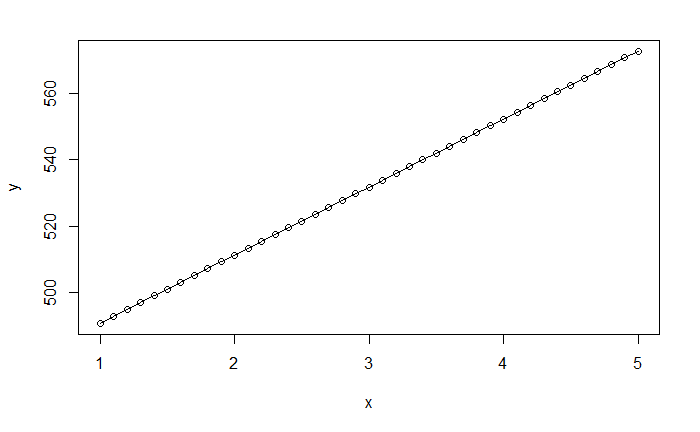

```r
plot(x,y)
lines(x,y)
```

```r
#predict(model, train_data,type = "response")
predicted<-predict(model3,train_data,type="response")
#predicted
predicted_class<-round(predicted)
train_data$class=predicted_class
conf_matrix<-table(actual=train_data$class,predicted=predicted_class)
conf_matrix
```

[output not shown]

[output cut: 34 more lines]

[output not shown]

```r
accuracy<-sum(diag(conf_matrix))/sum(conf_matrix)
accuracy
```

```
[1] 1
```

We can see the relationship between these variables appear to be moderately strong as shown by R-Squared value and the probability.also coclude from the p-value that sqft_living15 is not a significant variable for the prediction of price. Hence we drop it. ####We also try fitting the model including a few other variables which we left out in the EDA and stop at a model which gives us the maximum R-squared value.

#making decision trees

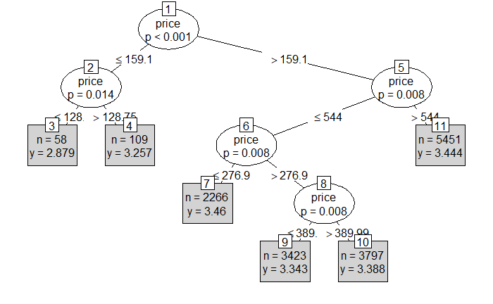

```r
#library(party)
project_ctree1 <- ctree(condition~price,data=train_data)
plot(project_ctree1, type="simple")
```

```r
#using decision trees for training and test set
#train_index1=sample(1:nrow(train_data),0.7*nrow(project))
train_index1=sample(c(TRUE, FALSE), nrow(project), replace=TRUE, prob=c(0.7,0.3))
train_set1=train_data[train_index1,]
test_set1=train_data[-train_index1,]

#run model on training set
project_ctree_model1 <- ctree(condition~price,data=train_data)
project_ctree_model1
```

```
     Conditional inference tree with 6 terminal nodes

Response:  condition
Input:  price
Number of observations:  15104

1) price <= 159.1; criterion = 0.999, statistic = 10.971
  2) price <= 128.75; criterion = 0.986, statistic = 6.098
    3)*  weights = 58
  2) price > 128.75
    4)*  weights = 109
1) price > 159.1
  5) price <= 544; criterion = 0.992, statistic = 7.068
    6) price <= 276.9; criterion = 0.992, statistic = 7.016
      7)*  weights = 2266
    6) price > 276.9
      8) price <= 389.99; criterion = 0.992, statistic = 7.051
        9)*  weights = 3423
      8) price > 389.99
        10)*  weights = 3797
  5) price > 544
    11)*  weights = 5451
```

```r
#prediction on test set
project_ctree_prediction1 <- predict(project_ctree_model1,test_data)
head(project_ctree_prediction1)
```

```
     condition
[1,]  3.443772
[2,]  3.443772
[3,]  3.459841
[4,]  3.388201
[5,]  3.388201
[6,]  3.388201
```

```r
#confusion matrix
table(project_ctree_prediction1,test_data$condition)
```

```
project_ctree_prediction1    1    2    3    4    5
         2.87931034482759    1    2   23    7    0
         3.25688073394495    1    4   32   15    3
         3.34326614081215    2    6  927  345   78
         3.38820121148275    2    6 1139  428   98
         3.44377178499358    1    6 1521  618  272
         3.45984112974404    1   25  549  326   71
```

```r
indep_train_data=train_data[-5]# making a independent set by removing target variable
indep_test_data=test_data[-5]
indep_test_data
```

|  | date | price | bedrooms | bathrooms | sqft_lot | floors | waterfront | view | condition | grade | sqft_above | sqft_basement | yr_built | yr_renovated | zipcode | lat | long | sqft_living15 | sqft_lot15 | class | age | reno |
| --- | --- | --- | --- | --- | --- | --- | --- | --- | --- | --- | --- | --- | --- | --- | --- | --- | --- | --- | --- | --- | --- | --- |
| 4 | 2014-12-09 | 604.000 | 4 | 3.00 | 5000 | 1.0 | 0 | 0 | 5 | 7 | 1050 | 910 | 1965 | 0 | 98136 | 47.5208 | -122.393 | 1360 | 5000 | 416 | 2009-07-23 | 0 |
| 6 | 2014-05-12 | 1230.000 | 4 | 4.50 | 101930 | 1.0 | 0 | 0 | 3 | 11 | 3890 | 1530 | 2001 | 0 | 98053 | 47.6561 | -122.005 | 4760 | 101930 | 1039 | 2008-11-18 | 0 |
| 7 | 2014-06-27 | 257.500 | 3 | 2.25 | 6819 | 2.0 | 0 | 0 | 3 | 7 | 1715 | 0 | 1995 | 0 | 98003 | 47.3097 | -122.327 | 2238 | 6819 | 381 | 2009-01-09 | 0 |
| 15 | 2015-03-12 | 530.000 | 5 | 2.00 | 4850 | 1.5 | 0 | 0 | 3 | 7 | 1810 | 0 | 1900 | 0 | 98107 | 47.6700 | -122.394 | 1360 | 4850 | 425 | 2009-12-28 | 0 |
| 17 | 2014-07-31 | 395.000 | 3 | 2.00 | 14040 | 2.0 | 0 | 0 | 3 | 7 | 1890 | 0 | 1994 | 0 | 98019 | 47.7277 | -121.962 | 1890 | 14018 | 407 | 2009-02-13 | 0 |
| 18 | 2014-05-29 | 485.000 | 4 | 1.00 | 4300 | 1.5 | 0 | 0 | 4 | 7 | 1600 | 0 | 1916 | 0 | 98103 | 47.6648 | -122.343 | 1610 | 4300 | 382 | 2009-02-28 | 0 |
| 20 | 2015-04-24 | 230.000 | 3 | 1.00 | 9774 | 1.0 | 0 | 0 | 4 | 7 | 1250 | 0 | 1969 | 0 | 98003 | 47.3343 | -122.306 | 1280 | 8850 | 394 | 2009-12-02 | 0 |
| 21 | 2014-05-14 | 385.000 | 4 | 1.75 | 4980 | 1.0 | 0 | 0 | 4 | 7 | 860 | 760 | 1947 | 0 | 98133 | 47.7025 | -122.341 | 1400 | 4980 | 368 | 2009-01-13 | 0 |
| 29 | 2014-06-24 | 438.000 | 3 | 1.75 | 6380 | 1.0 | 0 | 0 | 3 | 7 | 790 | 730 | 1948 | 0 | 98115 | 47.6950 | -122.304 | 1520 | 6235 | 373 | 2009-02-22 | 0 |
| 35 | 2014-12-03 | 322.500 | 4 | 2.75 | 6659 | 1.0 | 0 | 0 | 3 | 7 | 1280 | 780 | 1981 | 0 | 98058 | 47.4276 | -122.157 | 2020 | 8720 | 426 | 2009-07-01 | 0 |

[output cut: 990 more lines]

```r
target_train_data=train_data$sqft_living
target_test_data=test_data$sqft_living



# applying KNN
pred_target_test_set1=knn(indep_train_set1,indep_test_set1,target_train_set1,k=3)
table(pred_target_test_set1,target_test_set1)
```

[output not shown]

[output cut: 54 more lines]

[output not shown]

#applying kmean

```r
head(train_data)
```

|  | sqft_living | sqft_lot | floors | waterfront | view | condition | grade | sqft_above | sqft_basement | yr_built | yr_renovated | zipcode | lat | long | sqft_living15 | sqft_lot15 | age | reno | class |
| --- | --- | --- | --- | --- | --- | --- | --- | --- | --- | --- | --- | --- | --- | --- | --- | --- | --- | --- | --- |
| 1 | 1180 | 5650 | 1 | 0 | 0 | 3 | 7 | 1180 | 0 | 1955 | 0 | 98178 | 47.5112 | -122.257 | 1340 | 5650 | 2009-06-06 | 0 | 361 |
| 2 | 2570 | 7242 | 2 | 0 | 0 | 3 | 7 | 2170 | 400 | 1951 | 1991 | 98125 | 47.7210 | -122.319 | 1690 | 7639 | 2009-08-06 | 1 | 502 |
| 3 | 770 | 10000 | 1 | 0 | 0 | 3 | 6 | 770 | 0 | 1933 | 0 | 98028 | 47.7379 | -122.233 | 2720 | 8062 | 2009-11-10 | 0 | 270 |
| 5 | 1680 | 8080 | 1 | 0 | 0 | 3 | 8 | 1680 | 0 | 1987 | 0 | 98074 | 47.6168 | -122.045 | 1800 | 7503 | 2009-09-10 | 0 | 494 |
| 8 | 1060 | 9711 | 1 | 0 | 0 | 3 | 7 | 1060 | 0 | 1963 | 0 | 98198 | 47.4095 | -122.315 | 1650 | 9711 | 2009-08-31 | 0 | 354 |
| 9 | 1780 | 7470 | 1 | 0 | 0 | 3 | 7 | 1050 | 730 | 1960 | 0 | 98146 | 47.5123 | -122.337 | 1780 | 8113 | 2009-12-02 | 0 | 450 |

```r
project=project[-1]
kmean_housing=kmeans(project,5)
kmean_housing
```

```
K-means clustering with 5 clusters of sizes 275, 1282, 19845, 198, 13

Cluster means:
  bedrooms bathrooms sqft_living   sqft_lot   floors  waterfront      view condition    grade sqft_above
1 3.374545  2.407273    2838.455 153661.087 1.498182 0.003636364 0.3054545  3.323636 8.236364   2533.636
2 3.556162  2.395476    2741.583  47138.437 1.526521 0.029641186 0.3244930  3.407176 8.381435   2422.218
3 3.359133  2.088423    2018.607   7939.172 1.490829 0.006198035 0.2230285  3.411943 7.595717   1728.818
4 3.343434  2.483586    2801.939 270915.894 1.611111 0.005050505 0.6565657  3.297980 8.166667   2532.596
5 3.307692  2.826923    3350.385 971107.231 1.769231 0.000000000 0.6153846  3.307692 9.000000   3124.231
  sqft_basement yr_built yr_renovated  zipcode      lat      long sqft_living15 sqft_lot15
1      304.8182 1980.193    108.63273 98047.56 47.49298 -122.0451      2417.673  97841.189
2      319.3651 1978.321    108.79407 98053.50 47.55473 -122.0908      2581.341  41377.347
3      289.7891 1970.262     82.58468 98080.35 47.56223 -122.2263      1937.595   7626.519
4      269.3434 1984.712     80.53030 98040.02 47.47462 -122.0187      2432.566 206999.753
5      226.1538 1980.769      0.00000 98035.31 47.48468 -121.9971      2153.846 282947.692
```

[output cut: 32 more lines]

```r
table(project$condition,kmean_housing$cluster)
```

```
        1     2     3     4     5
  1     1     2    27     0     0
  2     7    15   145     4     1
  3   180   795 12905   143     8
  4    76   399  5162    39     3
  5    11    71  1606    12     1
```

[figure not shown]

```r
decompose(project)
```

```
Error in decompose(project) : time series has no or less than 2 periods
```